# EDA

In this hospital data analysis I will answer 5 key business questions:

1. Which states have the best-performing hospitals?
2. Does the size of the hospital impact the quality?
3. Are there noticeable differences between private and government-owned hospitals?
4. What should hospitals focus on to improve their overall rating?
5. How effectively do hospitals manage their capacity and staffing levels?

## Step 1: Loading the datasets

First we load the python packages that we need. For this analysis we use 2 datasets; the Hospital General Information file and the IME_GME2023 file. These files are stored and joined in a SQLite database.

```python
import sqlite3
import pandas as pd
import numpy as np
import matplotlib.pyplot as plt
import seaborn as sns
```

```python
#read in the CSV files
hospital_df = pd.read_csv('Hospital General Information.csv', encoding='windows-1252')
ime_gme_df = pd.read_csv('IME_GME2023.csv')

#connect and store into the database
conn = sqlite3.connect(':memory:')
hospital_df.to_sql('hospital', conn, index=False, if_exists='replace')
ime_gme_df.to_sql('ime_gme', conn, index=False, if_exists='replace')

#select the columns and rename them for more readability
hospital_cols = [
    ('Provider ID', 'provider_id'),
    ('Hospital Name', 'hospital_name'),
    ('Address', 'address'),
    ('City', 'city'),
    ('State', 'state'),
    ('ZIP Code', 'zip'),
    ('County Name', 'county'),
    ('Hospital Type', 'type'),
    ('Hospital Ownership', 'ownership'),
    ('Emergency Services', 'er'),
    ('meets criteria for meaningful use of EHRs', 'ehr_use'),
    ('Hospital overall rating', 'overall_rating'),
    ('Mortality national comparison', 'mortality'),
    ('Safety of care national comparison', 'safety'),
    ('Readmission national comparison', 'readmission'),
    ('Patient experience national comparison', 'experience'),
    ('Effectiveness of care national comparison', 'effectiveness'),
    ('Timeliness of care national comparison', 'timeliness'),
    ('Efficient use of medical imaging national comparison', 'efficiency')
]

ime_gme_cols = [
    ('Total_Hosp_Beds', 'beds'),
    ('Total_Hosp_Days', 'days'),
    ('Total_Hosp_Bed_Days_Available', 'bed_days_available'),
    ('Total_Hosp_Employees_on_Payroll', 'employees'),
    ('Total_Hosp_Discharges', 'discharges')
]

#make and run the sql query
hospital_sql = [f'h."{orig}" AS "{alias}"' for orig, alias in hospital_cols]
ime_gme_sql = [f'i."{orig}" AS "{alias}"' for orig, alias in ime_gme_cols]
select_clause = ",\n    ".join(hospital_sql + ime_gme_sql)

query = f"""
SELECT
    {select_clause}
FROM
    hospital h
JOIN
    ime_gme i
ON
    h."Provider ID" = i."provider_number"
"""

df = pd.read_sql_query(query, conn)
conn.close()
```

## Step 2: Inspecting the data

Now that the data is loaded we want to inspect the data to get a general understanding and to see if there is any cleaning needed before we can start analyzing it. There are 26 rows with missing data on total beds, total days, bed days available, etc. The reason for this is that these providers do not appear in the IME_GME dataset. As this is important data, we cannot use these rows and thus these are dropped. The other null values on county and ehr use (electronic health record) are likely less impactfull on the analysis and therefull will be imputed with 'Unknown'. If we have done that we see that we have 4458 rows with 24 columns that we can use for our analysis.

```python
df.head()
```

|  | provider_id | hospital_name | address | city | state | zip | county | type | ownership | er | ... | readmission | experience | effectiveness | timeliness | efficiency | beds | days | bed_days_available | employees | discharges |
| --- | --- | --- | --- | --- | --- | --- | --- | --- | --- | --- | --- | --- | --- | --- | --- | --- | --- | --- | --- | --- | --- |
| 0 | 10001 | SOUTHEAST ALABAMA MEDICAL CENTER | 1108 ROSS CLARK CIRCLE | DOTHAN | AL | 36301 | HOUSTON | Acute Care Hospitals | Government - Hospital District or Authority | Yes | ... | Same as the national average | Below the national average | Same as the national average | Same as the national average | Same as the national average | 345.0 | 102930.0 | 125925.0 | 2438.00 | 18800.0 |
| 1 | 10005 | MARSHALL MEDICAL CENTER SOUTH | 2505 U S HIGHWAY 431 NORTH | BOAZ | AL | 35957 | MARSHALL | Acute Care Hospitals | Government - Hospital District or Authority | Yes | ... | Above the national average | Same as the national average | Same as the national average | Above the national average | Below the national average | 182.0 | 34258.0 | 66430.0 | 1360.93 | 6846.0 |
| 2 | 10006 | ELIZA COFFEE MEMORIAL HOSPITAL | 205 MARENGO STREET | FLORENCE | AL | 35631 | LAUDERDALE | Acute Care Hospitals | Government - Hospital District or Authority | Yes | ... | Same as the national average | Below the national average | Same as the national average | Above the national average | Same as the national average | 223.0 | 67738.0 | 81618.0 | 1257.57 | 12547.0 |
| 3 | 10007 | MIZELL MEMORIAL HOSPITAL | 702 N MAIN ST | OPP | AL | 36467 | COVINGTON | Acute Care Hospitals | Voluntary non-profit - Private | Yes | ... | Below the national average | Same as the national average | Below the national average | Above the national average | Not Available | 45.0 | 5875.0 | 16425.0 | 166.89 | 1258.0 |
| 4 | 10008 | CRENSHAW COMMUNITY HOSPITAL | 101 HOSPITAL CIRCLE | LUVERNE | AL | 36049 | CRENSHAW | Acute Care Hospitals | Proprietary | Yes | ... | Same as the national average | Not Available | Same as the national average | Above the national average | Not Available | 29.0 | 1410.0 | 7917.0 | 84.94 | 290.0 |

5 rows × 24 columns

```python
df.isna().sum(axis=0)
```

```
provider_id            0
hospital_name          0
address                0
city                   0
state                  0
zip                    0
county                13
type                   0
ownership              0
er                     0
ehr_use               98
overall_rating         0
mortality              0
safety                 0
readmission            0
experience             0
effectiveness          0
timeliness             0
efficiency             0
beds                  26
days                  26
bed_days_available    26
employees             26
discharges            26
dtype: int64
```

```python
#drop specific columns with null values
col_drop = ['beds', 'days', 'bed_days_available', 'employees', 'discharges']
df = df.dropna(subset=col_drop)

#replace null values for unknown
df.loc[:, 'ehr_use'] = df['ehr_use'].fillna('Unknown')
df.loc[:, 'county'] = df['county'].fillna('Unknown')
```

```python
df.info()
```

```
<class 'pandas.core.frame.DataFrame'>
Index: 4458 entries, 0 to 4483
Data columns (total 24 columns):
 #   Column              Non-Null Count  Dtype
---  ------              --------------  -----
 0   provider_id         4458 non-null   int64
 1   hospital_name       4458 non-null   object
 2   address             4458 non-null   object
 3   city                4458 non-null   object
 4   state               4458 non-null   object
 5   zip                 4458 non-null   int64
 6   county              4458 non-null   object
 7   type                4458 non-null   object
 8   ownership           4458 non-null   object
 9   er                  4458 non-null   object
```

[output cut: 16 more lines]

To get a general understanding of the data I made some plots with Seaborn. These plots are not to directly answer business related questions but to see the distribution of the data, spot outliers and learn how the data might correlate.

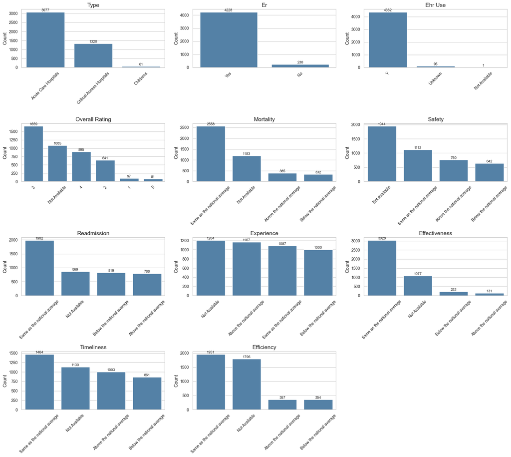

```python
#plots of the categorical columns with few values

#setup the style and fontsizes for the plots
sns.set(style="whitegrid")
plt.rcParams.update({'axes.titlesize': 14, 'xtick.labelsize': 10, 'ytick.labelsize': 10})

#select the columns
cat_cols = [
    'type', 'er', 'ehr_use',
    'overall_rating', 'mortality', 'safety', 'readmission',
    'experience', 'effectiveness', 'timeliness', 'efficiency'
]
#set the grid so it nicely spaces out
n_cols = 3
n_rows = (len(cat_cols) + n_cols - 1) // n_cols

fig, axes = plt.subplots(n_rows, n_cols, figsize=(18, n_rows * 4))
axes = axes.flatten()

#loop over the columns so that a plot is created for each column
for i, col in enumerate(cat_cols):
    order = df[col].value_counts().index
    sns.countplot(data=df, x=col, order=order, ax=axes[i], color='steelblue')

    axes[i].tick_params(axis='x', rotation=45)
    axes[i].set_title(f'{col.replace("_", " ").title()}')
    axes[i].set_xlabel('')
    axes[i].set_ylabel('Count')

    #add the numerical value on top of the bar
    for p in axes[i].patches:
        height = int(p.get_height())
        if height > 0:
            axes[i].annotate(f'{height}', (p.get_x() + p.get_width() / 2., height),
                             ha='center', va='bottom', fontsize=9)

#remove the last grid as no plot is shown there
for j in range(i + 1, len(axes)):
    fig.delaxes(axes[j])

plt.tight_layout()
plt.show()
```

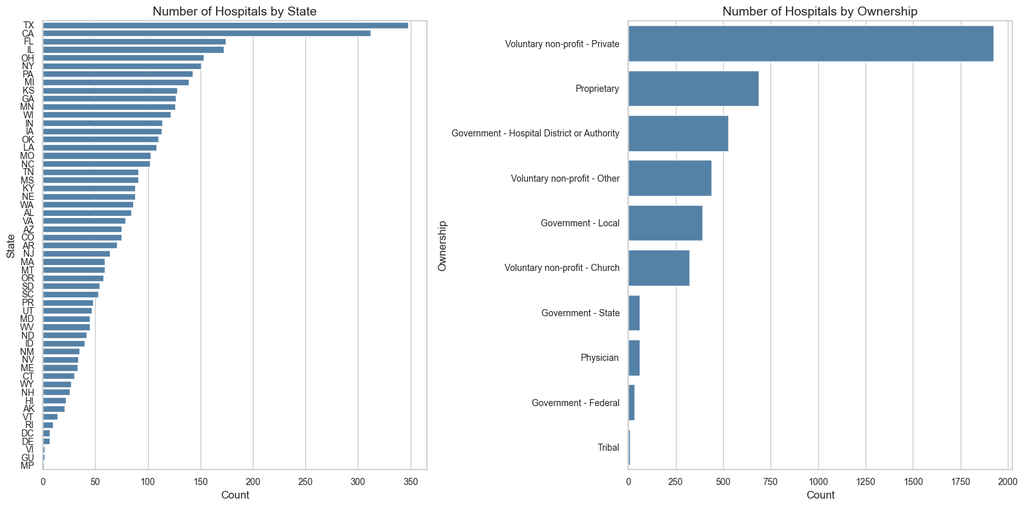

```python
#plots of the more detailed categorical columns

plt.figure(figsize=(16, 8))

#create plot of the number of hospitals by state
plt.subplot(1, 2, 1)
state_order = df['state'].value_counts().index
sns.countplot(data=df, y='state', order=state_order, color='steelblue')
plt.title('Number of Hospitals by State')
plt.xlabel('Count')
plt.ylabel('State')

#create plot of the number of hospitals by ownership
plt.subplot(1, 2, 2)
ownership_order = df['ownership'].value_counts().index
sns.countplot(data=df, y='ownership', order=ownership_order, color='steelblue')
plt.title('Number of Hospitals by Ownership')
plt.xlabel('Count')
plt.ylabel('Ownership')

plt.tight_layout()
plt.show()
```

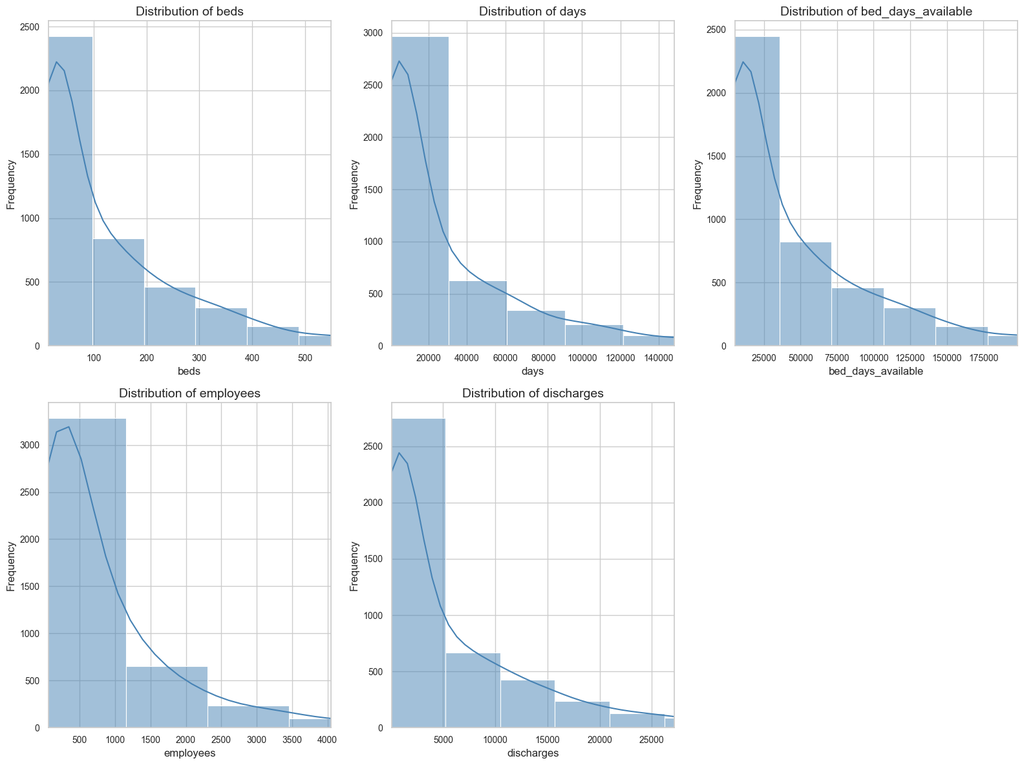

```python
#plots of the numerical columns

#select the numerical columns
num_cols = ['beds', 'days', 'bed_days_available', 'employees', 'discharges']

plt.figure(figsize=(16, 12))

#create a subbplot for each of the columns
for i, col in enumerate(num_cols):
    plt.subplot(2, 3, i+1)

    #use the 5 to 95 percentile to remove outliers from the plot -> otherwise the distribution not clearly visible
    lower = np.percentile(df[col], 5)
    upper = np.percentile(df[col], 95)

    sns.histplot(df[col], bins=30, kde=True, color='steelblue')
    plt.xlim(lower, upper)

    plt.title(f'Distribution of {col}')
    plt.xlabel(col)
    plt.ylabel('Frequency')

plt.tight_layout()
plt.show()
```

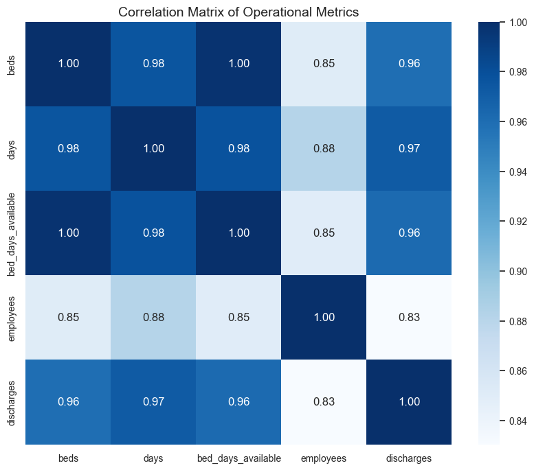

```python
#correlation map of the operational metrics
plt.figure(figsize=(10, 8))
corr = df[num_cols].corr()
sns.heatmap(corr, annot=True, cmap='Blues', fmt=".2f")
plt.title('Correlation Matrix of Operational Metrics')
plt.show()
```

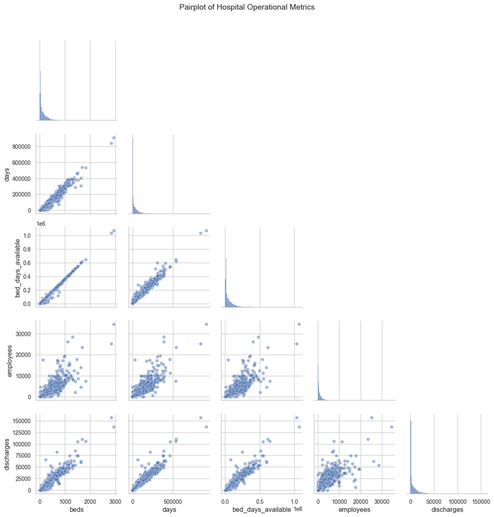

```python
#pairplot of the operational metrics
sns.pairplot(df[num_cols], corner=True, plot_kws={'alpha': 0.5})
plt.suptitle('Pairplot of Hospital Operational Metrics', fontsize=14, y=1.03)
plt.tight_layout()
plt.show()
```

## Step 3: Key business questions

Now that we have a general overview of the data we candive into it to answer the key business questions

### Which states have the best-performing hospitals?

To anwer this question I calculated the average score per state and than selected the top 5 best and worst states.

```python
#convert the overall rating to numeric values and drop the 'Not Available' in a new dataframe
df_ratings = df.copy()
df_ratings['overall_rating'] = pd.to_numeric(df_ratings['overall_rating'], errors='coerce')
df_ratings = df_ratings.dropna(subset=['overall_rating'])

#drop the rows which do not have a single overall_rating
df_ratings = df_ratings.groupby('state')['overall_rating'].mean().reset_index()
df_ratings = df_ratings.sort_values(by='overall_rating', ascending=False)

#compute the average rating per state
df_ratings = (
    df_ratings
    .groupby('state', observed=True)['overall_rating']
    .mean()
    .reset_index()
)

#sort the scores from best to worst
df_ratings = df_ratings.sort_values(by='overall_rating', ascending=False)

# Show the top 5 best and top 5 worst states
print('Top 5 states by average overall_rating:')
print(df_ratings.head(5).reset_index(drop=True))

print('\nBottom 5 states by average overall_rating:')
print(df_ratings.tail(5).reset_index(drop=True))
```

```
Top 5 states by average overall_rating:
  state  overall_rating
0    SD        3.846154
1    DE        3.666667
2    WI        3.609524
3    MN        3.539474
4    ID        3.526316

Bottom 5 states by average overall_rating:
  state  overall_rating
0    NV        2.400000
1    NY        2.323741
2    PR        2.111111
3    VI        2.000000
4    DC        1.500000
```

### Does the size of the hospital impact the quality?

Hospital size can be interpreted in different ways. In this analysis, I use two available measures as interpretation for size: the total number of beds and the total number of employees.

The charts suggest that larger hospitals tend to receive lower overall quality ratings. In both charts we observe that large hospitals are disproportionately represented in the lowest rating category 'way below average' (1). This trend is especially pronounced when considering the number of employees. Even though we can conclude that in general large hospitals score poorly, there seems to be a few exceptions. A small number of large hospitals achieved the highest rating 'way above average' (5). Small hospitals generally perform better; they are more frequently found in the 'average' to '(way) above average' rating categories (ratings 3 to 5). Therefore, we can say that if you go to a small hospital, it is more likely that you will recieve average or (way) above average quality.

In summary, smaller hospitals are more likely to receive higher overall quality ratings than larger hospitals. That said, hospital size alone does not guarantee the desired quality. Way above average but also way below average care can still be found across the size spectrum, but it is more likely that you will recieve excellent care within smaller facilities.

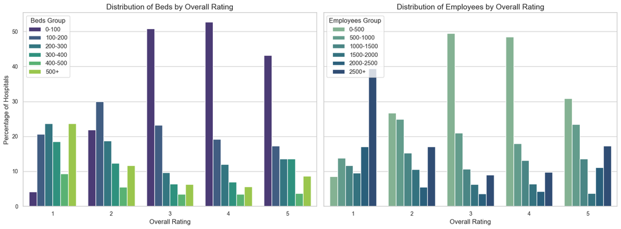

```python
#make a function where we process the data for plotting (so that we don't have to do it twice)
def distribution_by_rating(df, size_col, bins, labels, palette, ax):
    #convert the overall rating to numeric values so that we can drop the values where the rating is 'Not Available'
    df.loc[:, 'overall_rating'] = pd.to_numeric(df['overall_rating'], errors='coerce')
    df_clean = df.dropna(subset=['overall_rating', size_col]).copy()

    #create a column that will be used as bin later
    group_col = f"{size_col}_group"
    df_clean.loc[:, group_col] = pd.cut(df_clean[size_col], bins=bins, labels=labels, right=False)

    #count the relative percentage of the size within the bin rating group
    count_df = df_clean.groupby(['overall_rating', group_col], observed=True).size().reset_index(name='count')
    total_per_rating = count_df.groupby('overall_rating')['count'].transform('sum')
    count_df['percent'] = count_df['count'] / total_per_rating * 100
    #converting the overall_rating first to an integer and than to a string for better plotting quality
    count_df['overall_rating'] = count_df['overall_rating'].astype(int).astype(str)


    #setup for the barplots
    sns.barplot(
        data=count_df,
        x='overall_rating',
        y='percent',
        hue=group_col,
        palette=palette,
        ax=ax
    )

    ax.set_title(f'Distribution of {size_col.replace("_", " ").title()} by Overall Rating')
    ax.set_xlabel('Overall Rating')
    ax.set_ylabel('Percentage of Hospitals')
    ax.legend(title=f'{size_col.replace("_", " ").title()} Group', loc='upper left')

#setup grid for the plots
fig, axes = plt.subplots(1, 2, figsize=(16, 6), sharey=True)

#make the bins and labels for the beds and employees
beds_bins = [0, 100, 200, 300, 400, 500, 10000]
beds_labels = ['0-100', '100-200', '200-300', '300-400', '400-500', '500+']

emp_bins = [0, 500, 1000, 1500, 2000, 2500, 10000]
emp_labels = ['0-500', '500-1000', '1000-1500', '1500-2000', '2000-2500', '2500+']

#execute the code to plot hospital size vs overall rating
distribution_by_rating(df, 'beds', beds_bins, beds_labels, 'viridis', axes[0])
distribution_by_rating(df, 'employees', emp_bins, emp_labels, 'crest', axes[1])

plt.tight_layout()
plt.show()
```

### Are there noticable differences between private and governement owned hospitals?

To address this question, I divided hospitals into four ownership categories: Government, Proprietary (private), Voluntary Non-Profit, and Other. Note that the overall_rating metric uses a scale from 1 to 5, while the other measures use a scale from 1 to 3, where 1 indicates 'Below Average', 2 means 'Average', and 3 represents 'Above Average'.

Looking at overall rating the 'Other' hospital score signicifantly better than the other ownership types. Notably, government-owned hospitals also tend to offer better overall care compared to Proprietary hospitals. For the highest overall ratings, the best choices are 'Voluntary Non-Profit' and 'Other hospitals. A similar trend emerges when looking at overall patient experience. 'Other' hospitals receive an 'Above Average' rating roughly 80% of the time, with voluntary non-profit hospitals also performing well. In contrast, proprietary hospitals are more frequently rated as 'Below Average' for overall experience. 'Other' hospitals show a slightly higher mortality rates compared to other ownership types. This difference may be caused by factors such as patient demographics (e.g., older or sicker populations), the types of treatments offered, or the complexity of care provided. Also the efficiency scores of 'Other' hospitals show a markedly different distribution compared to other ownership categories, suggesting that they may be less efficient overall.

Concluding, ror the best overall ratings and patient experience, 'Voluntary Non-Profit' and 'Other' hospitals appear to be the top choices. Contrary to common belief, the data suggest that privately owned hospitals do not outperform government-owned hospitals. Government hospitals generally offer higher overall quality and patient experience.

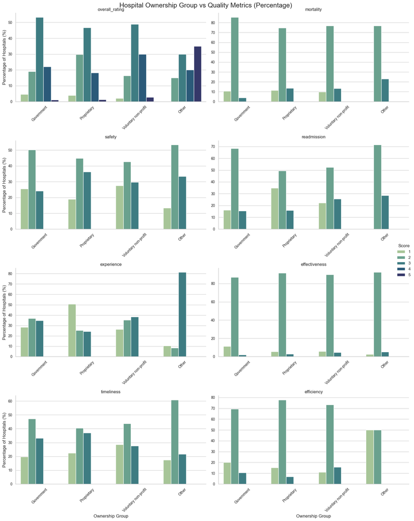

```python
#group the ownership types for better analysis
def group_ownership(x):
    if x.startswith('Government'):
        return 'Government'
    elif x == 'Proprietary':
        return 'Proprietary'
    elif x.startswith('Voluntary non-profit'):
        return 'Voluntary non-profit'
    else:
        return 'Other'

df['ownership_group'] = df['ownership'].apply(group_ownership)

#split the metrics in numeric and categorical metrics for further processing
numeric_metrics = ['overall_rating']
categorical_metrics = [
    'mortality', 'safety', 'readmission',
    'experience', 'effectiveness', 'timeliness', 'efficiency'
]

#convert the numeric to 'python' numeric values to make sure that the null values are handled correctly
df[numeric_metrics] = df[numeric_metrics].apply(pd.to_numeric, errors='coerce')

#remove the whitespace from the categorical metrics for correct further processing
for col in categorical_metrics:
    df[col] = df[col].astype(str).str.strip()

#reshape the data and so that every score becomes it's own row and remove the scores with null values
df_numeric = df.melt(
    id_vars='ownership_group',
    value_vars=numeric_metrics,
    var_name='Quality Metric',
    value_name='Score'
).dropna(subset=['Score'])

df_numeric['Score'] = df_numeric['Score'].astype(int).astype(str)

#set up a score map to later change the categorical values to a numeric score
score_map = {
    'Below the national average': '1',
    'Same as the national average': '2',
    'Above the national average': '3'
}

#reshape the data so that each score becomes it's own row
df_categorical = df.melt(
    id_vars='ownership_group',
    value_vars=categorical_metrics,
    var_name='Quality Metric',
    value_name='Score'
)

#drop the categorical values where the score is 'Non Availabe'
df_categorical = df_categorical[df_categorical['Score'] != 'Not Available']

#using mapping to change the categorical values into the numerical scores 1-3
df_categorical['Score'] = df_categorical['Score'].str.strip().map(score_map)

#drop rows where mapping failed
df_categorical = df_categorical.dropna(subset=['Score'])

#combine the numeric and categorical values back to one dataframe
df_all = pd.concat([df_numeric, df_categorical], axis=0).reset_index(drop=True)

#make sure score 4 and 5 is only represented in the overall rating
df_all = df_all[
    ( (df_all['Quality Metric'] == 'overall_rating') | (~df_all['Score'].isin(['4','5'])) )
]

#define the correct ordering of the columns
ownership_order = ['Government', 'Proprietary', 'Voluntary non-profit', 'Other']
df_all['ownership_group'] = pd.Categorical(df_all['ownership_group'], categories=ownership_order, ordered=True)

metric_order = ['overall_rating'] + categorical_metrics
df_all['Quality Metric'] = pd.Categorical(df_all['Quality Metric'], categories=metric_order, ordered=True)

#calculate the total percentages of a bar within the group
count_df = df_all.groupby(
    ['Quality Metric', 'ownership_group', 'Score'],observed=True).size().reset_index(name='count')

total_counts = count_df.groupby(
    ['Quality Metric', 'ownership_group'], observed=True)['count'].transform('sum')
count_df['percentage'] = 100 * count_df['count'] / total_counts

#sort the cores
count_df['Score'] = count_df['Score'].astype(int)
count_df = count_df.sort_values(['Quality Metric', 'ownership_group', 'Score'])

#setup the frame of the plots
g = sns.catplot(
    data=count_df,
    x='ownership_group',
    y='percentage',
    hue='Score',
    col='Quality Metric',
    kind='bar',
    col_wrap=2,
    height=5,
    aspect=1.5,
    palette='crest',
    sharex=False,
    sharey=False
)
#make the plots
g.set_titles('{col_name}')
g.set_axis_labels('Ownership Group', 'Percentage of Hospitals (%)')
g.set_xticklabels(rotation=45)
g.fig.suptitle('Hospital Ownership Group vs Quality Metrics (Percentage)', fontsize=18)

plt.tight_layout()
plt.show()
```

### What should hospitals focus on to improve their overall rating?

Patient experience shows the strongest positive correlation with overall rating, suggesting that factors like communication quality, comfort, responsiveness, and staff-patient interactions significantly influence patients’ overall perception of the hospital. Improving patient experience may be the most effective way for hospitals to boost their overall ratings.

Readmission and safety also show a moderate positive correlation with overall rating. This indicates that hospitals with better safety records and lower rates of patient readmission ((that is, patients needing to return after discharge)) tend to receive higher overall ratings. This indicates that patiens highly value a hospital's effectiveness in preventing complications and ensuring successful treatment, so they don't have to return in a later stage. For hospitals, this may mean that taking more time to ensure treatment is thorough and effective is preferable to trying to treat patients as quickly as possible at the risk of higher readmission rates. Mortality shows a weaker positive correlation with overall rating. This might be because mortality rates can be influenced by factors beyond hospital control, such as patient demographics and disease severity. Additionally, mortality is less visible or directly perceived by patients, so it may not heavily impact their overall rating.

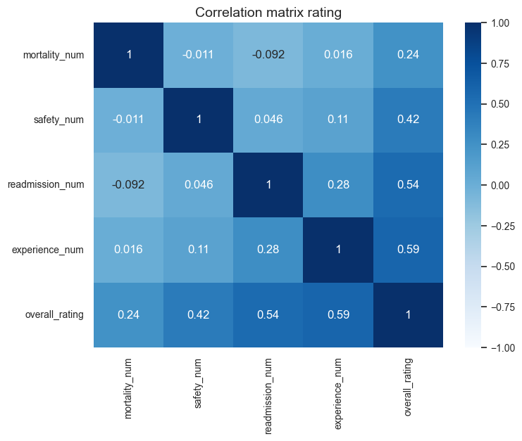

```python
#make a mapping dictonairy to later chance the categorical values into numerical values
mapping = {
    'Below the national average': 1,
    'Same as the national average': 2,
    'Above the national average': 3,
    'Not Available': np.nan
}

#change the numerical values into categorical values to be able to see a correlation
for col in ['mortality', 'safety', 'readmission', 'experience']:
    df[col] = df[col].astype(str).str.strip()
    df[col + '_num'] = df[col].map(mapping)

#select the applicable columns and drop any columns with 'Not Available'
cols = ['mortality_num', 'safety_num', 'readmission_num', 'experience_num', 'overall_rating']
corr_df = df[cols].dropna()

#calculate and plot the correlation matrix
corr_matrix = corr_df.corr(method='spearman')
plt.figure(figsize=(8,6))
sns.heatmap(corr_matrix, annot=True, cmap='Blues', vmin=-1, vmax=1)
plt.title('Correlation matrix rating')
plt.show()
```

### How effectively do hospitals manage their capacity and staffing levels?

An interesting conclusion we can draw from the correlation matrix is that there is a strong positive correlation between occupancy rate and discharges per employee. This suggests that hospitals with higher occupancy rates tend to discharge more patients per staff member, potentially reflecting increased operational pressure and efficiency demands. Conversely, there is a moderate negative correlation between the staff-to-bed ratio and discharges per employee. This indicates that hospitals with more staff tend to have fewer discharges per employee. One possible interpretation is that when occupancy is lower and staff have more time per patient, they may provide longer or more comprehensive care, resulting in lower discharge rates. In contrast, higher occupancy could push hospitals to prioritize efficiency, leading to shorter stays and more discharges per staff member.

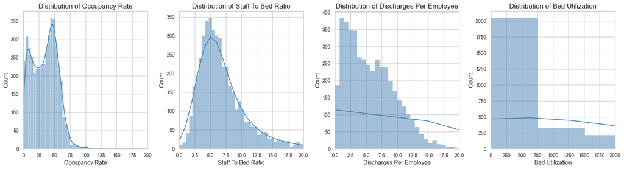

```
                         occupancy_rate  staff_to_bed_ratio  \
occupancy_rate                 1.000000            0.311605
staff_to_bed_ratio             0.311605            1.000000
discharges_per_employee        0.719290           -0.338806
bed_utilization                0.845389            0.157649

                         discharges_per_employee  bed_utilization
occupancy_rate                          0.719290         0.845389
staff_to_bed_ratio                     -0.338806         0.157649
discharges_per_employee                 1.000000         0.731455
bed_utilization                         0.731455         1.000000
```

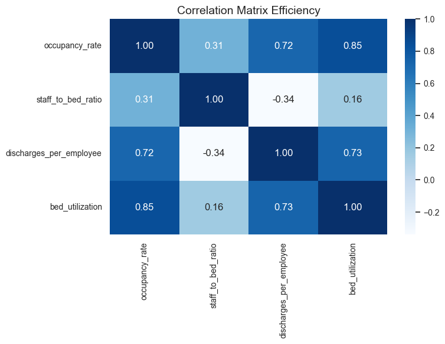

```python
#select the columns we will use as measures and remove the rows that do not have any rating
capacity_cols = ['beds', 'discharges', 'employees', 'bed_days_available', 'days']
df_effect = df.dropna(subset=capacity_cols)
df_effect = df_effect[
    (df_effect['beds'] > 0) &
    (df_effect['employees'] > 0) &
    (df_effect['discharges'] > 0) &
    (df_effect['days'] > 0) &
    (df_effect['bed_days_available'] > 0)
].copy()

#calculation of measures we use to measure the efficiency
df_effect['occupancy_rate'] = df_effect['discharges'] / df_effect['beds']
df_effect['staff_to_bed_ratio'] = df_effect['employees'] / df_effect['beds']
df_effect['discharges_per_employee'] = df_effect['discharges'] / df_effect['employees']
df_effect['bed_utilization'] = df_effect['discharges'] / (df_effect['bed_days_available'] / df_effect['days'])

#set up distribution plots of the four metrics
fig, axes = plt.subplots(1, 4, figsize=(18, 5))
metrics = ['occupancy_rate', 'staff_to_bed_ratio', 'discharges_per_employee','bed_utilization']
xlims = {
    'occupancy_rate': (0, 200),
    'staff_to_bed_ratio': (0, 20),
    'discharges_per_employee': (0, 20),
    'bed_utilization': (0, 2000)
}

#draw the distribution plots
for ax, metric in zip(axes.flatten(), metrics):
    sns.histplot(df_effect[metric], kde=True, ax=ax, color='steelblue')
    ax.set_title(f'Distribution of {metric.replace('_', ' ').title()}')
    ax.set_xlabel(metric.replace('_', ' ').title())
    ax.set_xlim(xlims[metric])

plt.tight_layout()
plt.show()

#calculate and plot the correlation matrix
corr_matrix = df_effect[['occupancy_rate', 'staff_to_bed_ratio', 'discharges_per_employee', 'bed_utilization']].corr(method='spearman')
print(corr_matrix)
plt.figure(figsize=(8, 6))
sns.heatmap(corr_matrix, annot=True, cmap='Blues', fmt=".2f")
plt.title('Correlation Matrix Efficiency')
plt.tight_layout()
plt.show()
```